# Machine Learning in Python: Support Vector Machines

⇦ Back

Support vector machines (SVMs) are *supervised* learning models that can be used either for *classification* or *regression*. This tutorial will create one for classification: it will be used to predict a discrete label from inputs that are continuous.

SVMs are fast because they only use the *support vectors* in their algorithm. This keeps the computation lightweight.

See the Wikipedia pages for [support vector machines](https://en.wikipedia.org/wiki/Support_vector_machine) and [supervised learning models](https://en.wikipedia.org/wiki/Supervised_learning) for more info.

# 1 Python Packages

The code on this page uses the scikit-learn, Matplotlib, NumPy and pandas packages. These can be installed from the terminal with the following commands:

```bash
# "python3.12" corresponds to the version of Python you have installed and are using
$ python3.12 -m pip install scikit-learn
$ python3.12 -m pip install matplotlib
$ python3.12 -m pip install numpy
$ python3.12 -m pip install pandas
```

Once finished installing, import these packages into your Python script as follows:

```python
from sklearn import datasets
from sklearn import svm
from matplotlib import pyplot as plt
from matplotlib import colors as mcolors
import numpy as np
import pandas as pd
```

# 2 Example Data

For this example we will use the *Iris* toy dataset from scikit-learn.

- See [here](https://scikit-learn.org/stable/datasets/toy_dataset.html#iris-dataset) for the user guide
- See [here](https://scikit-learn.org/stable/modules/generated/sklearn.datasets.load_iris.html) for the documentation of the `load_iris()` function which imports this dataset
- See [here](https://scikit-learn.org/stable/auto_examples/datasets/plot_iris_dataset.html) for an example on the scikit-learn site
- See here for an example on my site
- See [here](https://en.wikipedia.org/wiki/Iris_flower_data_set) for the Wikipedia page about this dataset

This dataset can be loaded using the `load_iris()` function from scikit-learn’s `datasets` sub-module. Using the `as_frame=True` option means that the data will be formatted as a pandas data frame:

```python
# Load the dataset
dataset = datasets.load_iris(as_frame=True)
```

For this example we will only use two of the four **features**: sepal length and sepal width:

```python
# Separate out the features
X = dataset['data']
cols = ['sepal length (cm)', 'sepal width (cm)']
X = X[cols]

# View the first five rows
print(X.head())
```

```
##    sepal length (cm)  sepal width (cm)
## 0                5.1               3.5
## 1                4.9               3.0
## 2                4.7               3.2
## 3                4.6               3.1
## 4                5.0               3.6
```

Note that these features are contained in a *two-column data frame*. Some of the functions we will use later on will require the data to be in a *2D array*, but this is not a problem because the functions will convert to this format automatically. In other words, there is no need to *reshape* our data - if we were only using one feature we would not be able to skip this step.

The **target** will be the species of *Iris* flower that corresponds to each specimen:

```python
# Separate out the target
y = dataset['target']
```

By default the target values are the numbers 0, 1 and 2, but these can be ‘translated’ into their actual values (the species names ‘setosa’, ‘virginica’ and ‘versicolor’) which are stored in the `'target_names'` key:

```python
# Translate the target
y = y.apply(lambda x: dataset['target_names'][x])

# View the first five values
print(y.head())
```

```
## 0    setosa
## 1    setosa
## 2    setosa
## 3    setosa
## 4    setosa
## Name: target, dtype: object
```

For this example were are only going to use the data from the ‘setosa’ and ‘versicolor’ plants, so let’s remove the ‘virginica’ plants:

```python
# Only use two species
X = X[y != 'virginica']
y = y[y != 'virginica']
```

# 3 Visualise the Data

Let’s have a look at the raw data:

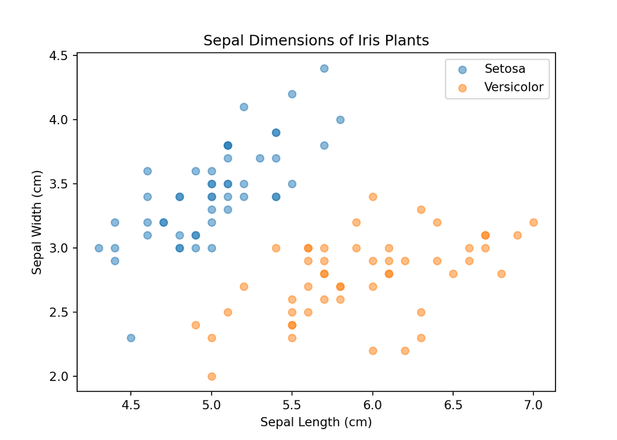

```python
# Plot
ax = plt.axes()
for i, group in enumerate(y.unique()):
    x = X[y == group]
    ax.scatter(
        x['sepal length (cm)'], x['sepal width (cm)'],
        c=list(mcolors.TABLEAU_COLORS)[i], label=group.capitalize(), alpha=0.5
    )
ax.set_title('Sepal Dimensions of Iris Plants')
ax.set_ylabel('Sepal Width (cm)')
ax.set_xlabel('Sepal Length (cm)')
ax.legend()
plt.show()
plt.close()
```

# 4 Create the Model

This will use the `svm.SVC()` function from scikit-learn.

- See [here](https://scikit-learn.org/stable/modules/svm.html) for the user guide
- See [here](https://scikit-learn.org/stable/modules/generated/sklearn.svm.SVC.html) for the documentation
- See [here](https://scikit-learn.org/stable/auto_examples/svm/plot_custom_kernel.html) for an example (which also uses the *Iris* dataset)

The hyperparameter *C* - the *regularization parameter* - determines how much error the SVM will allow for. A large value for *C* will result in a model that has little error and a small margin (a small distance between the support vectors and the decision boundary). This ‘hard margin’ won’t allow for many misclassifications but it will come at the risk of *overfitting* the data and being influenced too much by outliers. Decreasing *C* will increase the error and the margin and so will risk *underfitting* and not being representative of the training data, but then the model will be more resistant to outliers.

Here, we create the model with a regularization parameter (*C*-value) of 20:

```python
# Create a support vector machine
model = svm.SVC(kernel='linear', C=20)
# Fit the model
model.fit(X, y)
```

We have used the `'linear'` kernel above as opposed to the default which is `'rbf'` or ‘radial basis function’. RBF uses `gamma` as its hyperparameter instead of `C` but the concept is the same: a higher gamma will put more importance on the training data and could result in overfitting while a lower gamma makes the points in the training data less relevant and can result in underfitting.

# 5 Visualise the Model

We can re-plot the data with the decision boundary and support vectors added in:

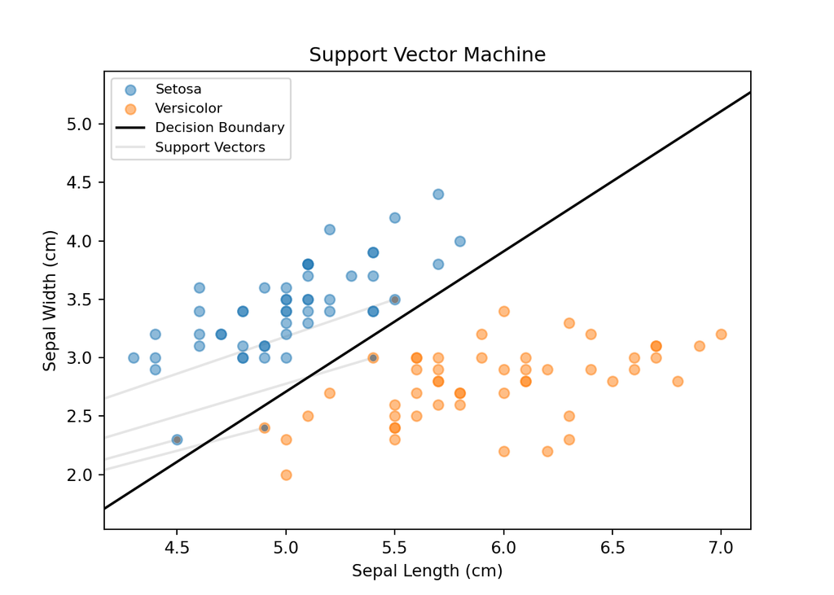

```python
# Plot
ax = plt.axes()
for i, species in enumerate(y.unique()):
    x = X[y == species]
    ax.scatter(
        x['sepal length (cm)'], x['sepal width (cm)'],
        c=list(mcolors.TABLEAU_COLORS)[i], label=species.capitalize(),
        alpha=0.5
    )
ax.set_title('Support Vector Machine')
ax.set_ylabel('Sepal Width (cm)')
ax.set_xlabel('Sepal Length (cm)')
# Decision boundary
left, right = ax.get_xlim()
w = model.coef_[0]
b = model.intercept_[0]
x_points = np.linspace(left, right)
y_points = -(w[0] / w[1]) * x_points - b / w[1]
ax.plot(x_points, y_points, c='k', label='Decision Boundary')
ax.set_xlim(left, right)
# Support vectors
top, bottom = ax.get_ylim()
first_vector = True
for sv_x, sv_y in model.support_vectors_:
    if first_vector:
        ax.plot(
            [0, sv_x], [0, sv_y], c='gray', alpha=0.2, zorder=0,
            label='Support Vectors'
        )
        first_vector = False
    else:
        ax.plot([0, sv_x], [0, sv_y], c='gray', alpha=0.2, zorder=0)
    ax.scatter(sv_x, sv_y, c='grey', s=10)
ax.set_ylim(top, bottom)
# Finished
plt.legend(fontsize='small')
plt.show()
```

Essentially, this model is saying that the species of any *Iris* flower that lies above/left of the **decision boundary** (the black line) should be classified as ‘setosa’, and that of any flower below/right of the decision boundary should be ‘versicolor’. The model is using four **support vectors** (in grey) to define this decision boundary and the distance from the boundary to the nearest data points is the **margin**. SVMs attempt to create the largest margin possible while staying within an acceptable amount of error.

# 6 Make Predictions

If we are given four new *Iris* flowers with sepal lengths of 6.5, 6.5, 6.3 and 6.3 centimeters and sepal widths of 4.5, 4.8, 4.7 and 4.2 cm what species do we think they are?

```python
# Make predictions
X_test = pd.DataFrame({
    'sepal length (cm)': [6.5, 6.5, 6.3, 6.3],
    'sepal width (cm)': [4.5, 4.8, 4.7, 4.2]
})
y_pred = model.predict(X_test)

print(y_pred)
```

```
## ['versicolor' 'setosa' 'setosa' 'versicolor']
```

# 7 Visualise the Predictions

We can re-plot the data with the predictions added in:

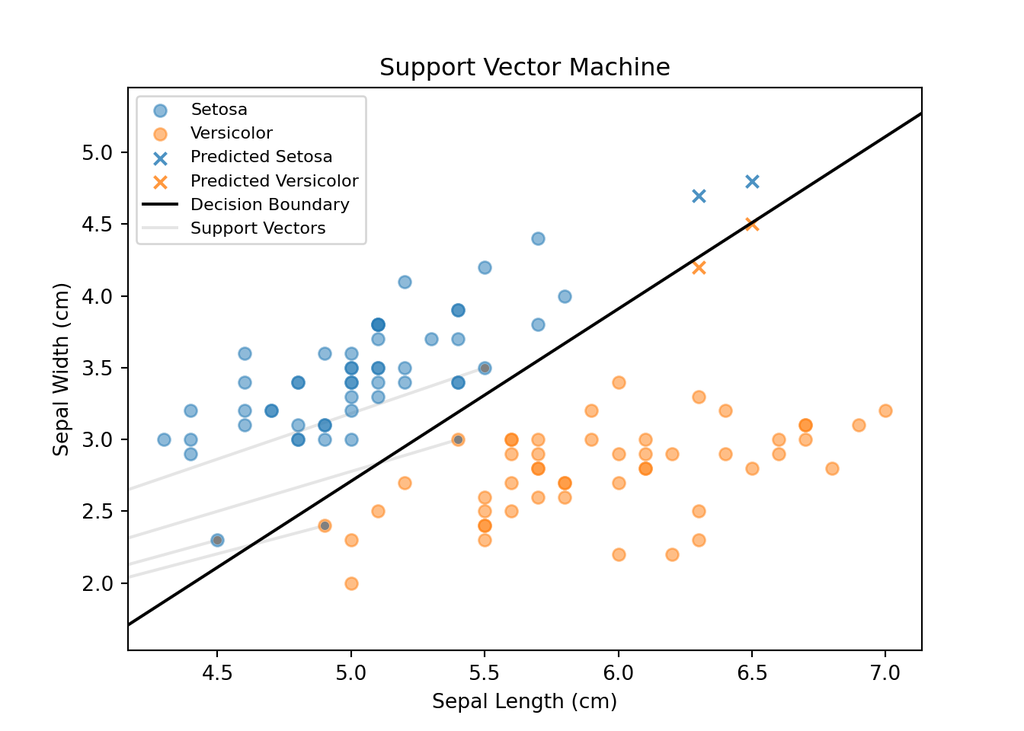

```python
# Plot
ax = plt.axes()
for i, species in enumerate(y.unique()):
    x = X[y == species]
    ax.scatter(
        x['sepal length (cm)'], x['sepal width (cm)'],
        c=list(mcolors.TABLEAU_COLORS)[i], label=species.capitalize(),
        alpha=0.5
    )
ax.set_title('Support Vector Machine')
ax.set_ylabel('Sepal Width (cm)')
ax.set_xlabel('Sepal Length (cm)')
# Predictions
for species in y.unique():
    x = X_test[y_pred == species]
    label = f'Predicted {species.capitalize()}'
    ax.scatter(
        x['sepal length (cm)'], x['sepal width (cm)'],
        marker='x', label=label, alpha=0.8
    )
# Decision boundary
left, right = ax.get_xlim()
w = model.coef_[0]
b = model.intercept_[0]
x_points = np.linspace(left, right)
y_points = -(w[0] / w[1]) * x_points - b / w[1]
ax.plot(x_points, y_points, c='k', label='Decision Boundary')
ax.set_xlim(left, right)
# Support vectors
top, bottom = ax.get_ylim()
first_vector = True
for sv_x, sv_y in model.support_vectors_:
    if first_vector:
        ax.plot(
            [0, sv_x], [0, sv_y], c='gray', alpha=0.2, zorder=0,
            label='Support Vectors'
        )
        first_vector = False
    else:
        ax.plot([0, sv_x], [0, sv_y], c='gray', alpha=0.2, zorder=0)
    ax.scatter(sv_x, sv_y, c='grey', s=10)
ax.set_ylim(top, bottom)
# Finished
plt.legend(fontsize='small')
plt.show()
```

As can be seen, the ‘test’ data points that lie above/left of the decision boundary have been classified as ‘setosa’, while the points below/right of the boundary have been classified as ‘versicolor’.

⇦ Back